# Summary of the fitted operating models

ABT-MSE

Tom Carruthers

February 14, 2019

# 1 Introduction / notes

This is a report of various M vectors and sensitivity to previous data.

# 2 OM design

# 3 OMs presented in this report

Table 1. The subset of wider operating models included in this comparison report.

| OM |
| --- |
| Rev_PSAT |
| Rev_PSAT_CAR |
| Rev_PSAT_2 |
| Rev_PSAT_3 |
| M1 |
| M2 |
| M3 |
| M4 |

# 4 Residuals in indices

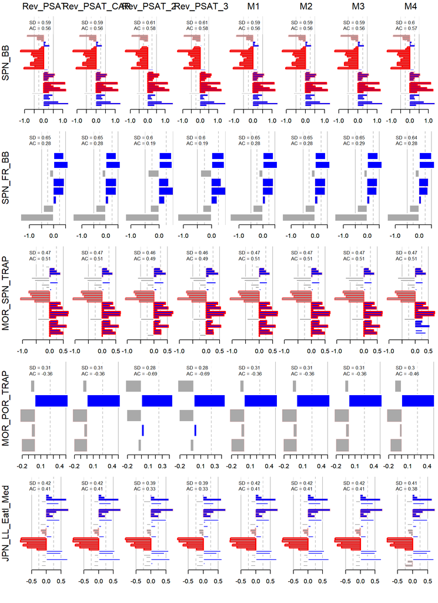

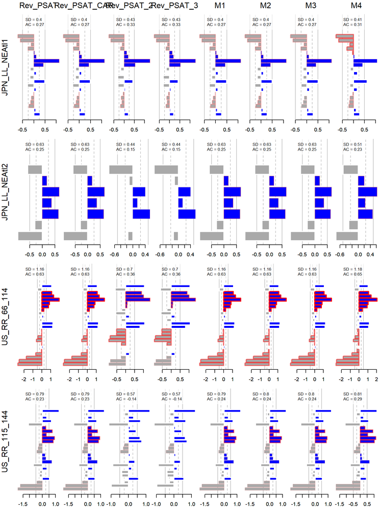

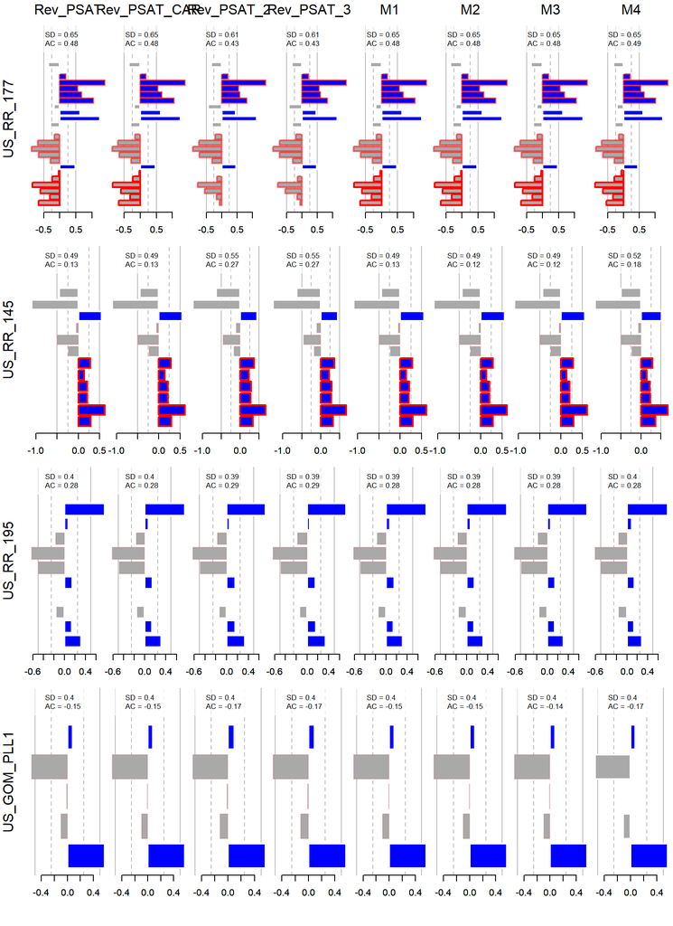

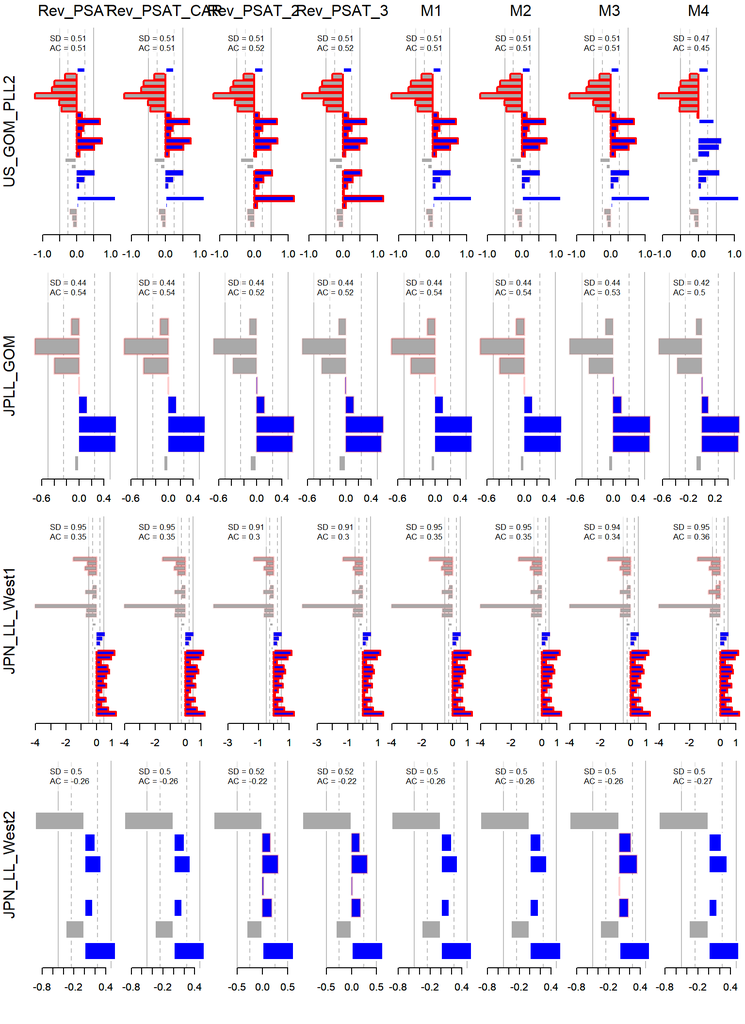

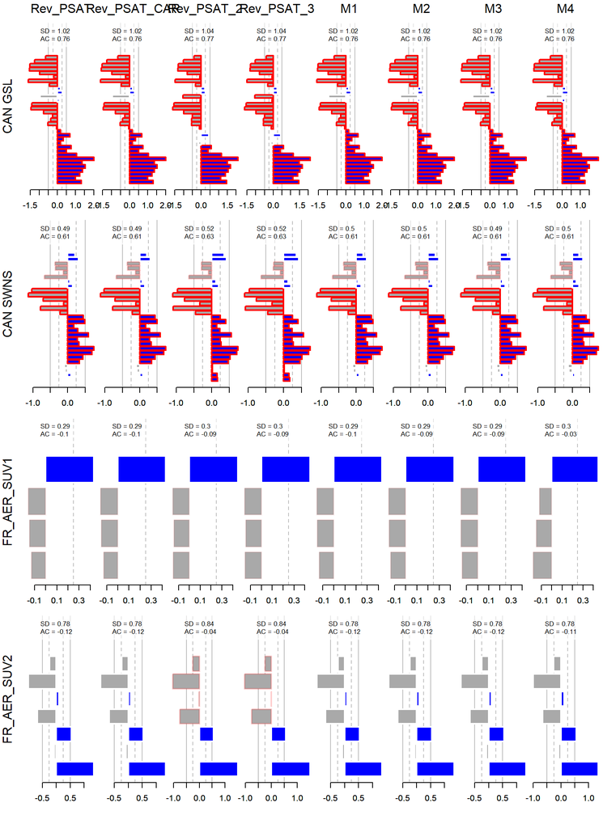

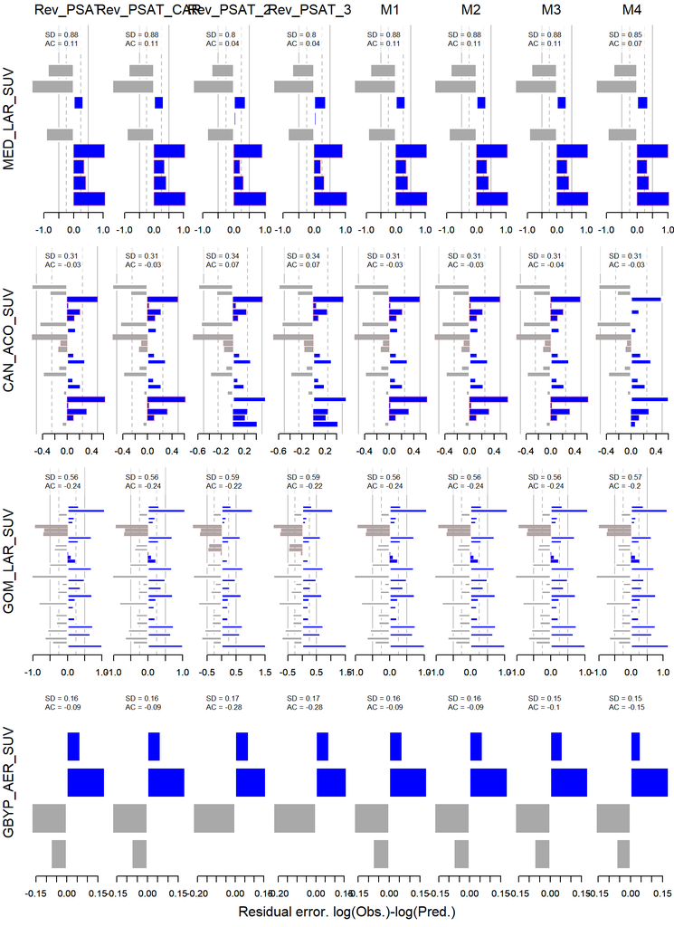

# 5 Spawning stock biomass trends by stock and area

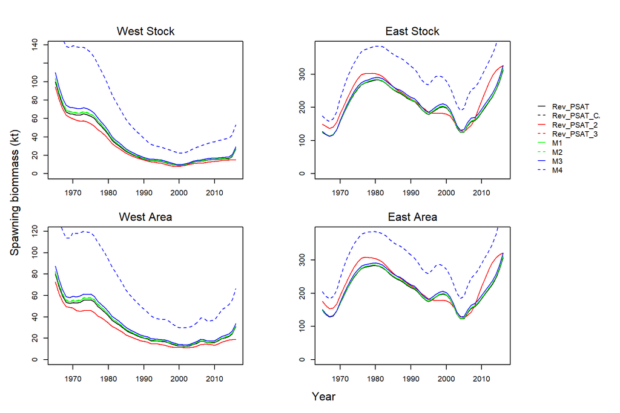

# 6 Model estimates / reference points

## 6.1 Eastern stock

| OM | Code | MSY | FMSY | BMSY | BMSY_B0 | F_FMSY | B_BMSY | Dep |
| --- | --- | --- | --- | --- | --- | --- | --- | --- |
| Rev_PSAT | Rev_PSAT | 49429 | 0.673 | 568579 | 0.361 | 0.591 | 0.55 | 0.232 |
| Rev_PSAT_CAR | Rev_PSAT_CAR | 49429 | 0.673 | 568579 | 0.361 | 0.591 | 0.55 | 0.232 |
| Rev_PSAT_2 | Rev_PSAT_2 | 48585 | 0.455 | 589063 | 0.361 | 0.667 | 0.553 | 0.232 |
| Rev_PSAT_3 | Rev_PSAT_3 | 48585 | 0.455 | 589063 | 0.361 | 0.667 | 0.553 | 0.232 |
| M1 | M1 | 49544 | 0.679 | 552291 | 0.362 | 0.582 | 0.573 | 0.242 |
| M2 | M2 | 49559 | 0.681 | 543007 | 0.362 | 0.577 | 0.584 | 0.247 |
| M3 | M3 | 50079 | 0.694 | 549020 | 0.376 | 0.547 | 0.595 | 0.261 |
| M4 | M4 | 54963 | 0.837 | 616482 | 0.412 | 0.35 | 0.784 | 0.375 |

## 6.2 Western stock

| OM | Code | MSY | FMSY | BMSY | BMSY_B0 | F_FMSY | B_BMSY | Dep |
| --- | --- | --- | --- | --- | --- | --- | --- | --- |
| Rev_PSAT | Rev_PSAT | 3309 | 0.121 | 42528 | 0.305 | 1.547 | 0.624 | 0.22 |
| Rev_PSAT_CAR | Rev_PSAT_CAR | 3309 | 0.121 | 42528 | 0.305 | 1.547 | 0.624 | 0.22 |
| Rev_PSAT_2 | Rev_PSAT_2 | 2827 | 0.096 | 42464 | 0.315 | 2.141 | 0.351 | 0.125 |
| Rev_PSAT_3 | Rev_PSAT_3 | 2827 | 0.096 | 42464 | 0.315 | 2.141 | 0.351 | 0.125 |
| M1 | M1 | 3302 | 0.121 | 39210 | 0.305 | 1.502 | 0.698 | 0.246 |
| M2 | M2 | 3302 | 0.121 | 37940 | 0.305 | 1.484 | 0.73 | 0.257 |
| M3 | M3 | 3330 | 0.123 | 37147 | 0.308 | 1.37 | 0.791 | 0.282 |
| M4 | M4 | 3954 | 0.127 | 43526 | 0.321 | 0.696 | 1.219 | 0.452 |

# 7 SSB trends by stock

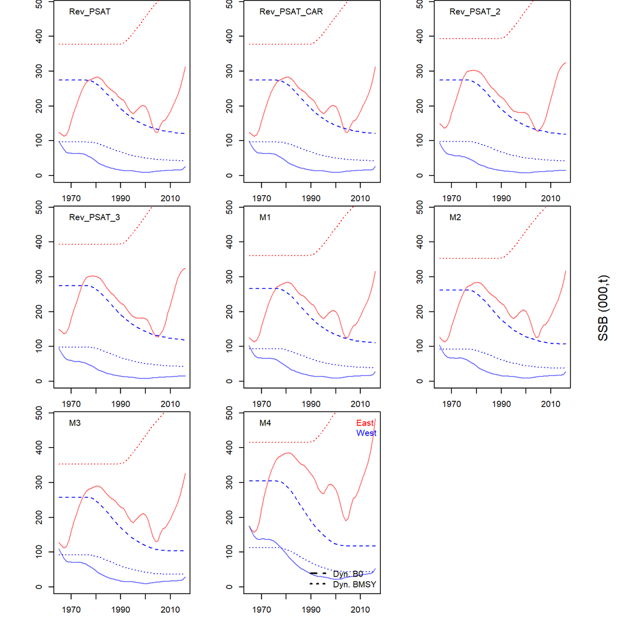

# 8 Negative log-likelihood components

Table 3. Contribution of negative log-likelihood components (lower values are better fit) to global objective function. Each likelihood component has a specific weighting that is documented in the trial specifications.

| OM | Code | Catch | CPUE | Survey | L Comp | SOO | PSAT | Rec Dev | Mov Pr | Sel Pr | SRA pen | SSB Pr | Dep Pr | MI Pr | TOT |
| --- | --- | --- | --- | --- | --- | --- | --- | --- | --- | --- | --- | --- | --- | --- | --- |
| 1 | Rev_PSAT | 2777.0 | 19.3 | 246.2 | 87.1 | 1483.0 | 774.0 | 62.1 | 3.1 | 1.0 | 0.3 | 0 | 0 | 46.7 | 5526.7 |
| 2 | Rev_PSAT_CAR | 2777.0 | 19.3 | 246.2 | 87.1 | 1483.0 | 774.0 | 62.1 | 3.1 | 1.0 | 0.3 | 0 | 0 | 46.7 | 5526.7 |
| 3 | Rev_PSAT_2 | 8158.2 | 15.9 | 272.1 | 117.3 | 1533.3 | 786.1 | 46.6 | 3.1 | 0.9 | 0.5 | 0 | 0 | 47.5 | 11008.8 |
| 4 | Rev_PSAT_3 | 8158.2 | 15.9 | 272.1 | 117.3 | 1533.3 | 786.1 | 46.6 | 3.1 | 0.9 | 0.5 | 0 | 0 | 47.5 | 11008.8 |
| 5 | M1 | 2776.8 | 19.3 | 246.2 | 87.8 | 1483.6 | 773.6 | 62.5 | 3.1 | 1.0 | 0.2 | 0 | 0 | 46.4 | 5527.9 |
| 6 | M2 | 2776.9 | 19.3 | 246.2 | 88.9 | 1484.1 | 773.5 | 62.6 | 3.1 | 1.0 | 0.2 | 0 | 0 | 46.3 | 5529.7 |
| 7 | M3 | 2777.0 | 19.3 | 247.3 | 90.5 | 1485.8 | 773.4 | 64.3 | 3.2 | 1.0 | 0.2 | 0 | 0 | 46.2 | 5536.1 |
| 8 | M4 | 2763.8 | 19.2 | 260.1 | 82.1 | 1493.7 | 768.2 | 70.0 | 3.3 | 1.0 | 0.0 | 0 | 0 | 45.1 | 5535.4 |

Catch = catch data by fleet, quarter and area. CPUE = the fishery dependent CPUE indices, Survey = fishery-independent indices, L Comp = length composition data, SOO = stock of origin data, PSAT = Electronic tagging data, Rec Dev = prior on recruitment deviations, Mov Pr = prior on movement parameters, Sel Pr = prior on size selectivity parameters, SRA pen = penalty incurred when catches exceed F=1 catches in the stock reduction analysis phase (1864-1964), SSB Pr = a prior on spawning stock biomass by area for reference operating models B (match VPA assessments), Dep Pr = a prior on stock depletion since 1980 to generate more depleted stocks for refernece operating models C (historically low stock levels), MI Pr = a prior on similarlity to the ‘Master Index’ that predicts F by year, area, season and fleet, TOT = total global objective function.